# Part II - Factors associated with Diabetes among females of Pima Indian Heritage

## by Eric Anku

## Investigation Overview

This investigation explored factors associated with diabetes among females of Pima Indian Heritage 21 years and older. Participants with diabetes were on average older than participants without diabetes. The chances of diabetes increased with increasing number of pregnancies, blood pressure, triceps skinfold thinckness and BMI. Participants with diabetes had higher amounts of serum insulin compared to participants without diabetes and a higher Diabetes Pedigree Funtion on average was also associated with increased chances of having diabetes. Participants with diabetes had higher blood glucose 2 hours after oral glucose test.

## Dataset Overview

The dataset consisted of 768 observation with 9 features. The main outcome in the dataset was diabetes among females of Pima Indian Heritage. Explanatory features in the dataset includes number of pregnancies, serum glucose, insulin, blood pressure, tricep skinfold thickness, BMI, Diabetes Pedigree Function, and age.

## (Visualization 1)

Number of pregnancies is associated with the outcome of diabetes among females of Pima Indian heritage. The average number of pregnancies for participants without diabetes is 2 where as that of participants with diabetes is 3.

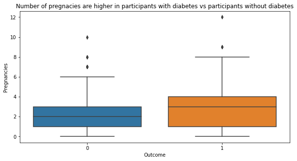

## (Visualization 2)

The average pressure of participants with diabetes is higher compared to participants without diabetes. However, participants without diabetes have overall higher blood pressure compared to participants without diabetes.

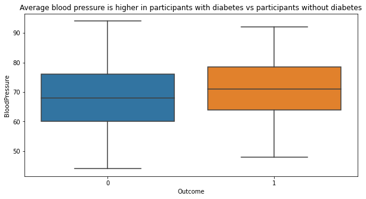

## (Visualization 3)

Average skinfold thickness in participants with diabetes is higher compared to that of participants without diabetes. However, participants without diabetes have higher skinfold thickness overall compared to participants without diabtes.

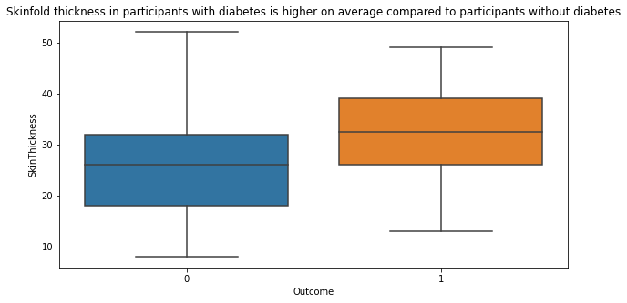

## (Visualization 4)

Average insulin concentration in participants with diabetes is higher compared to that of participants without diabetes.

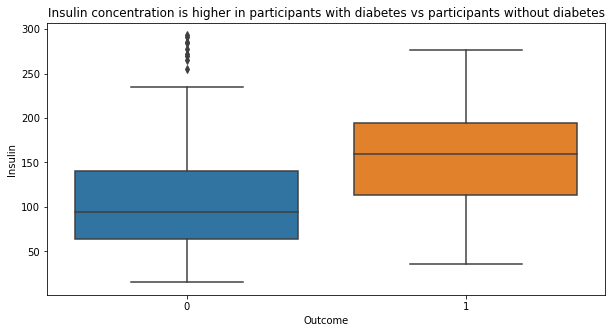

## (Visualization 5)

Average body mass index (BMI) in participants with diabetes is higher compared to that of participants without diabetes. However, participants without diabetes have higher BMI overall compared to participants without diabtes

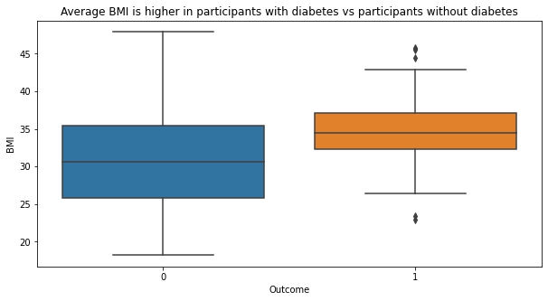

## (Visualization 6)

Diabetes pedigree function is on average higher in participants with diabetes is higher compared to that of participants without diabetes.

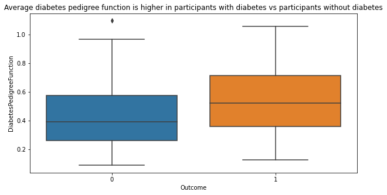

## (Visualization 7)

Serum glucose after 2h oral glucose tolerance test in participants with diabetes is higher compared to that of participants without diabetes.

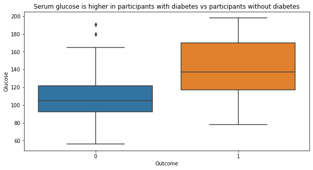

## (Visualization 8)

Participants with diabetes are on average older compared to participants without diabetes.

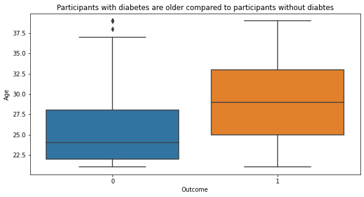

## (Visualization 9)

Participants with diabetes have higher concentrations of both glucose and insulin.

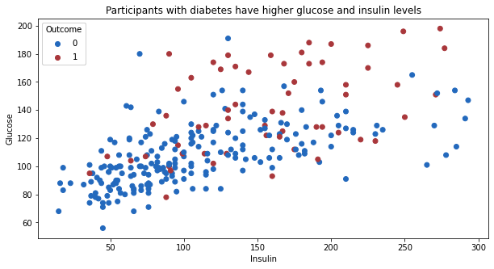